# QMSS5074GR - Final Project (3rd)

### Your Grp ID: [Group 4]

### Your UNIs: [jy3339_mz3067_hy2855_bc3149]

### Your Full Names: [Min Zhuang, Jie Yuan, Justin Yu, Buirui Chen]

### Public GitHub Repo: [https://github.com/michellezzmmmmm/QMSS5074/tree/main/HW3]

## Part 1 – Data Ingestion & Preprocessing

1. **Data Loading**
   - Acquire the Stanford Sentiment Treebank dataset.
   - Split into training, validation and test sets with stratified sampling to preserve class balance.
   - Clearly document your splitting strategy and resulting dataset sizes.
2. **Text Cleaning & Tokenization**
   - Implement a reusable preprocessing pipeline that handles at least:
     - HTML removal, lowercasing, punctuation stripping
     - Vocabulary pruning (e.g., rare words threshold)
     - Tokenization (character- or word-level)
   - Expose this as a function/class so it can be saved and re-loaded for inference.
3. **Feature Extraction**
   - **Traditional**: Build a TF-IDF vectorizer (or n-gram count) pipeline.
   - **Neural**: Prepare sequences for embedding—pad/truncate to a fixed length.
   - Save each preprocessor (vectorizer/tokenizer) to disk.

## Part 2 – Exploratory Data Analysis (EDA)

1. **Class Distribution**
   - Visualize the number of positive vs. negative reviews.
   - Compute descriptive statistics on review lengths (mean, median, IQR).
2. **Text Characteristics**
   - Plot the 20 most frequent tokens per sentiment class.
   - Generate word clouds (or bar charts) highlighting key terms for each class.
3. **Correlation Analysis**
   - Analyze whether review length correlates with sentiment.
   - Present findings numerically and with at least one visualization.

## Part 3 – Baseline Traditional Models

1. **Logistic Regression & SVM**
   - Train at least two linear models on your TF-IDF features (e.g., logistic regression, linear SVM).
   - Use cross-validation (≥ 5 folds) on the training set to tune at least one hyperparameter.
2. **Random Forest & Gradient Boosting**
   - Train two tree-based models (e.g., Random Forest, XGBoost) on the same features.
   - Report feature-importance for each and discuss any notable tokens.
3. **Evaluation Metrics**
   - Compute accuracy, precision, recall, F1-score, and ROC-AUC on the **held-out test set**.
   - Present all results in a single comparison table.

## Part 4 – Neural Network Models

1. **Simple Feed-Forward**
   - Build an embedding layer + a dense MLP classifier.
   - Ensure you freeze vs. unfreeze embeddings in separate runs.
2. **Convolutional Text Classifier**
   - Implement a 1D-CNN architecture (Conv + Pooling) for sequence data.
   - Justify your choice of kernel sizes and number of filters.
3. **Recurrent Model (Optional)**
   - (Stretch) Add an RNN or Bi-LSTM layer and compare performance/time vs. CNN.

## Part 5 – Transfer Learning & Advanced Architectures

1. **Pre-trained Embeddings**
   - Retrain one network using pre-trained GloVe (or FastText) embeddings.
   - Compare results against your from-scratch embedding runs.
2. **Transformer Fine-Tuning**
   - Fine-tune a BERT-family model on the training data.
   - Clearly outline your training hyperparameters (learning rate, batch size, epochs).

## Part 6 – Hyperparameter Optimization

1. **Search Strategy**
   - Use a library (e.g., Keras Tuner, Optuna) to optimize at least two hyperparameters of one deep model.
   - Describe your search space and stopping criteria.
2. **Results Analysis**
   - Report the best hyperparameter configuration found.
   - Plot validation-loss (or metric) vs. trials to illustrate tuning behavior.

## Part 7 – Final Comparison & Error Analysis

1. **Consolidated Results**
   - Tabulate test-set performance for **all** models (traditional, neural, transfer-learned).
   - Highlight top‐performing model overall and top in each category.
2. **Statistical Significance**
   - Perform a significance test (e.g., McNemar’s test) between your best two models.
3. **Error Analysis**
   - Identify at least 20 examples your best model misclassified.
   - For a sample of 5, provide the raw text, predicted vs. true label, and a short discussion of each error—what linguistic artifact might have confused the model?

## Part 8 – Optional Challenge Extensions

- Implement data augmentation for text (back-translation, synonym swapping) and measure its impact.
- Integrate a sentiment lexicon feature (e.g., VADER scores) into your models and assess whether it improves predictions.
- Deploy your best model as a simple REST API using Flask or FastAPI and demo it on a handful of user‐submitted reviews.

## Start coding .....

ps. the code below is just an filler code with some tips on the top it.

But the main project requirements are listed above in the description.

```python
from google.colab import drive
drive.mount('/content/drive')
import os
os.chdir('/content/drive/MyDrive/ADMLHW3')
```

```python
!pip install tensorflow transformers datasets keras-tuner nlpaug vaderSentiment flask
```

[output not shown]

## Part 1 – Data Ingestion & Preprocessing

1. **Data Loading**
   - Acquire the Stanford Sentiment Treebank dataset.
   - Split into training, validation, and test sets with stratified sampling to preserve class balance.
   - Clearly document your splitting strategy and resulting dataset sizes.

```python
# Load data (example)
import pandas as pd


# IMPORT DATA
!git clone https://github.com/YJiangcm/SST-2-sentiment-analysis.git
!ls SST-2-sentiment-analysis/data
```

```
fatal: destination path 'SST-2-sentiment-analysis' already exists and is not an empty directory.
dev.tsv  test.tsv  train.tsv
```

```python
train_df = pd.read_csv('SST-2-sentiment-analysis/data/train.tsv', sep='\t', header=None).rename(columns={0: 'sentiment', 1: 'review'})
val_df = pd.read_csv('SST-2-sentiment-analysis/data/dev.tsv', sep='\t', header=None).rename(columns={0: 'sentiment', 1: 'review'})
test_df = pd.read_csv('SST-2-sentiment-analysis/data/test.tsv', sep='\t', header=None).rename(columns={0: 'sentiment', 1: 'review'})
display(train_df.head())
display(val_df.head())
display(test_df.head())
```

|  | sentiment | review |
| --- | --- | --- |
| 0 | 1 | a stirring , funny and finally transporting re... |
| 1 | 0 | apparently reassembled from the cutting-room f... |
| 2 | 0 | they presume their audience wo n't sit still f... |
| 3 | 1 | this is a visually stunning rumination on love... |
| 4 | 1 | jonathan parker 's bartleby should have been t... |

|  | sentiment | review |
| --- | --- | --- |
| 0 | 0 | one long string of cliches . |
| 1 | 0 | if you 've ever entertained the notion of doin... |
| 2 | 0 | k-19 exploits our substantial collective fear ... |
| 3 | 0 | it 's played in the most straight-faced fashio... |
| 4 | 1 | there is a fabric of complex ideas here , and ... |

|  | sentiment | review |
| --- | --- | --- |
| 0 | 0 | no movement , no yuks , not much of anything . |
| 1 | 0 | a gob of drivel so sickly sweet , even the eag... |
| 2 | 0 | gangs of new york is an unapologetic mess , wh... |
| 3 | 0 | we never really feel involved with the story ,... |
| 4 | 1 | this is one of polanski 's best films . |

```python
dfs = [train_df, val_df, test_df]
for df in dfs:
    print(f"Shape of DataFrame: {df.shape}")
    print(f"Value counts for 'sentiment' column:")
    print(df['sentiment'].value_counts())
    print("-" * 20)
print('These datasets are already balanced!')
```

```
Shape of DataFrame: (6920, 2)
Value counts for 'sentiment' column:
sentiment
1    3610
0    3310
Name: count, dtype: int64
--------------------
Shape of DataFrame: (872, 2)
Value counts for 'sentiment' column:
sentiment
1    444
0    428
Name: count, dtype: int64
--------------------
Shape of DataFrame: (1821, 2)
Value counts for 'sentiment' column:
sentiment
0    912
1    909
Name: count, dtype: int64
--------------------
These datasets are already balanced!
```

2. **Text Cleaning & Tokenization**
   - Implement a reusable preprocessing pipeline that handles at least:
     - HTML removal, lowercasing, punctuation stripping
     - Vocabulary pruning (e.g., rare words threshold)
     - Tokenization (character- or word-level)
   - Expose this as a function/class so it can be saved and re-loaded for inference.

```python
import re
from collections import Counter

def preprocess_text(text):
    # HTML removal
    text = re.sub(r'<.*?>', '', text)
    # Lowercasing
    text = text.lower()
    # Punctuation stripping
    text = re.sub(r'[^\w\s]', '', text)
    return text


def vocabulary_pruning(df, column_name, min_occurrence=5):
    # Combine all reviews into a single string
    all_text = ' '.join(df[column_name].astype(str))
    # Count word occurrences
    word_counts = Counter(all_text.split())

    # Filter out words with less than min_occurrence
    vocabulary = [word for word, count in word_counts.items() if count >= min_occurrence]

    def prune_text(text):
        words = text.split()
        pruned_words = [word for word in words if word in vocabulary]
        return ' '.join(pruned_words)

    df[column_name] = df[column_name].astype(str).apply(prune_text)
    return df, vocabulary

# Example usage (assuming your dataframe is named 'train_df' and the column with reviews is named 'cleaned_review'):
train_df['cleaned_review'] = train_df['review'].apply(preprocess_text)
train_df, vocabulary = vocabulary_pruning(train_df, 'cleaned_review', min_occurrence=5)
display(train_df.head())
print(vocabulary[:20]) #print first 20 words in vocabulary
```

|  | sentiment | review | cleaned_review |
| --- | --- | --- | --- |
| 0 | 1 | a stirring , funny and finally transporting re... | a stirring funny and finally of beauty and the... |
| 1 | 0 | apparently reassembled from the cutting-room f... | apparently from the floor of any given soap |
| 2 | 0 | they presume their audience wo n't sit still f... | they their audience wo nt sit still for a less... |
| 3 | 1 | this is a visually stunning rumination on love... | this is a visually stunning on love memory his... |
| 4 | 1 | jonathan parker 's bartleby should have been t... | parker s should have been the of the films |

```
['a', 'stirring', 'funny', 'and', 'finally', 'of', 'beauty', 'the', 'beast', 'horror', 'films', 'apparently', 'from', 'floor', 'any', 'given', 'soap', 'they', 'their', 'audience']
```

```python
import pandas as pd
import re
from collections import Counter
import nltk
nltk.download('stopwords')
from nltk.corpus import stopwords
stop_words = set(stopwords.words('english'))

def preprocess_text(text, min_word_frequency=5):
    text = re.sub(r'<.*?>', '', text)  # HTML removal
    text = text.lower()  # Lowercasing
    text = re.sub(r'[^\w\s]', '', text) # Punctuation stripping
    text = re.sub(r'\W+', ' ', text)  # Remove non-alphanumeric characters
    text = re.sub(r'[^a-zA-Z]+', ' ', text) # clearly keep only the alphanumeric characters
    words = text.split()
    words = [word for word in words if word not in stop_words]
    text = ' '.join(words)

    return text


def apply_preprocessing(df, min_word_frequency=1):
    df['cleaned_review'] = df['review'].apply(lambda x: preprocess_text(x, min_word_frequency))
    return df

train_df = apply_preprocessing(train_df)
val_df = apply_preprocessing(val_df)
test_df = apply_preprocessing(test_df)

def vocabulary_pruning(df, column_name, min_occurrence=2):
    all_text = ' '.join(df[column_name].astype(str))
    word_counts = Counter(all_text.split())
    vocabulary = [word for word, count in word_counts.items() if count >= min_occurrence]
    return vocabulary

vocabulary = vocabulary_pruning(train_df, 'cleaned_review', min_occurrence=5)
print(len(vocabulary), 'words in vocabulary')

train_df['cleaned_review'] = train_df['cleaned_review'].apply(lambda x: ' '.join([word for word in x.split() if word in vocabulary]))
val_df['cleaned_review'] = val_df['cleaned_review'].apply(lambda x: ' '.join([word for word in x.split() if word in vocabulary]))
test_df['cleaned_review'] = test_df['cleaned_review'].apply(lambda x: ' '.join([word for word in x.split() if word in vocabulary]))

train_df['cleaned_review_tokenized'] = train_df['cleaned_review'].apply(lambda x: x.split())
val_df['cleaned_review_tokenized'] = val_df['cleaned_review'].apply(lambda x: x.split())
test_df['cleaned_review_tokenized'] = test_df['cleaned_review'].apply(lambda x: x.split())

display(train_df.head())
display(val_df.head())
display(test_df.head())
```

```
2739 words in vocabulary
```

|  | sentiment | review | cleaned_review | cleaned_review_tokenized |
| --- | --- | --- | --- | --- |
| 0 | 1 | a stirring , funny and finally transporting re... | stirring funny finally beauty beast horror films | [stirring, funny, finally, beauty, beast, horr... |
| 1 | 0 | apparently reassembled from the cutting-room f... | apparently floor given soap | [apparently, floor, given, soap] |
| 2 | 0 | they presume their audience wo n't sit still f... | audience wo nt sit still lesson however presen... | [audience, wo, nt, sit, still, lesson, however... |
| 3 | 1 | this is a visually stunning rumination on love... | visually stunning love memory history war art | [visually, stunning, love, memory, history, wa... |
| 4 | 1 | jonathan parker 's bartleby should have been t... | parker films | [parker, films] |

|  | sentiment | review | cleaned_review | cleaned_review_tokenized |
| --- | --- | --- | --- | --- |
| 0 | 0 | one long string of cliches . | one long string cliches | [one, long, string, cliches] |
| 1 | 0 | if you 've ever entertained the notion of doin... | ever notion title film sex actually shows may ... | [ever, notion, title, film, sex, actually, sho... |
| 2 | 0 | k-19 exploits our substantial collective fear ... | k substantial fear holocaust generate cheap ho... | [k, substantial, fear, holocaust, generate, ch... |
| 3 | 0 | it 's played in the most straight-faced fashio... | played fashion little humor things | [played, fashion, little, humor, things] |
| 4 | 1 | there is a fabric of complex ideas here , and ... | complex ideas | [complex, ideas] |

|  | sentiment | review | cleaned_review | cleaned_review_tokenized |
| --- | --- | --- | --- | --- |
| 0 | 0 | no movement , no yuks , not much of anything . | much anything | [much, anything] |
| 1 | 0 | a gob of drivel so sickly sweet , even the eag... | sweet even eager moore like | [sweet, even, eager, moore, like] |
| 2 | 0 | gangs of new york is an unapologetic mess , wh... | gangs new york mess whose saving grace ends ev... | [gangs, new, york, mess, whose, saving, grace,... |
| 3 | 0 | we never really feel involved with the story ,... | never really feel involved story ideas remain ... | [never, really, feel, involved, story, ideas, ... |
| 4 | 1 | this is one of polanski 's best films . | one polanski best films | [one, polanski, best, films] |

A preprocessing function, `preprocess_text`, is defined to remove HTML tags, convert text to lowercase, and strip punctuation. Another function `apply_preprocessing` applies this function to each review in the DataFrames, creating a new `cleaned_review` column. The code then displays the preprocessed datasets. The steps of vocabulary pruning and tokenization are also implemented

3. **Feature Extraction**
   - **Traditional**: Build a TF-IDF vectorizer (or n-gram count) pipeline.
   - **Neural**: Prepare sequences for embedding—pad/truncate to a fixed length.
   - Save each preprocessor (vectorizer/tokenizer) to disk.

```python
from sklearn.feature_extraction.text import TfidfVectorizer

# Initialize TF-IDF Vectorizer
vectorizer = TfidfVectorizer(max_features=2000)

# Fit on cleaned text
DTM_train = vectorizer.fit_transform(train_df['cleaned_review'])    # FIT transform!
DTM_val = vectorizer.transform(val_df['cleaned_review'])        # transform!
DTM_test = vectorizer.transform(test_df['cleaned_review'])       # transform!
print(DTM_train.shape)  # Output feature shape
print(DTM_train.shape)
print(DTM_train.shape)
```

```
(6920, 2000)
(6920, 2000)
(6920, 2000)
```

```python
print(vectorizer.get_feature_names_out()[:50])
```

```
['abandon' 'ability' 'able' 'absolutely' 'absorbing' 'absurd' 'accessible'
 'accomplished' 'account' 'achievement' 'achieves' 'achingly' 'across'
 'act' 'acted' 'acting' 'action' 'actor' 'actors' 'actress' 'actresses'
 'acts' 'actually' 'adam' 'adaptation' 'add' 'addition' 'adds' 'admirable'
 'admire' 'admit' 'adolescent' 'adult' 'adults' 'advantage' 'adventure'
 'adventures' 'affair' 'affecting' 'affection' 'afraid' 'age' 'ages' 'ago'
 'aimed' 'aims' 'air' 'alabama' 'alive' 'allen']
```

```python
import numpy as np
from tensorflow.keras.preprocessing.text import Tokenizer
from tensorflow.keras.preprocessing.sequence import pad_sequences

max_sequence_length = 100  # Adjust as needed
tokenizer = Tokenizer()
tokenizer.fit_on_texts(train_df['cleaned_review'])

# Convert text to sequences
train_sequences = tokenizer.texts_to_sequences(train_df['cleaned_review'])
val_sequences = tokenizer.texts_to_sequences(val_df['cleaned_review'])
test_sequences = tokenizer.texts_to_sequences(test_df['cleaned_review'])

# Pad sequences
X_train_seq = pad_sequences(train_sequences, maxlen=max_sequence_length)
X_val_seq = pad_sequences(val_sequences, maxlen=max_sequence_length)
X_test_seq = pad_sequences(test_sequences, maxlen=max_sequence_length)
```

```python
print("Training sequence shape:", X_train_seq.shape)
print("Validation sequence shape:", X_val_seq.shape)
print("Test sequence shape:", X_test_seq.shape)

#Example of accessing a specific sequence
print("Example of a sequence in the training set:")
print(X_train_seq[0])
```

```
Training sequence shape: (6920, 100)
Validation sequence shape: (872, 100)
Test sequence shape: (1821, 100)
Example of a sequence in the training set:
[   0    0    0    0    0    0    0    0    0    0    0    0    0    0
    0    0    0    0    0    0    0    0    0    0    0    0    0    0
    0    0    0    0    0    0    0    0    0    0    0    0    0    0
    0    0    0    0    0    0    0    0    0    0    0    0    0    0
    0    0    0    0    0    0    0    0    0    0    0    0    0    0
    0    0    0    0    0    0    0    0    0    0    0    0    0    0
    0    0    0    0    0    0    0    0    0 1265   15  414  494 1894
  236   43]
```

These are just token ids with correct sequence!

```python
import pickle

# Save the TF-IDF vectorizer
with open('tfidf_vectorizer.pickle', 'wb') as f:
    pickle.dump(vectorizer, f)

# Save the tokenizer
with open('padding_tokenizer.pickle', 'wb') as f:
    pickle.dump(tokenizer, f)
```

## Part 2 – Exploratory Data Analysis (EDA)

1. **Class Distribution**
   - Visualize the number of positive vs. negative reviews.
   - Compute descriptive statistics on review lengths (mean, median, IQR).

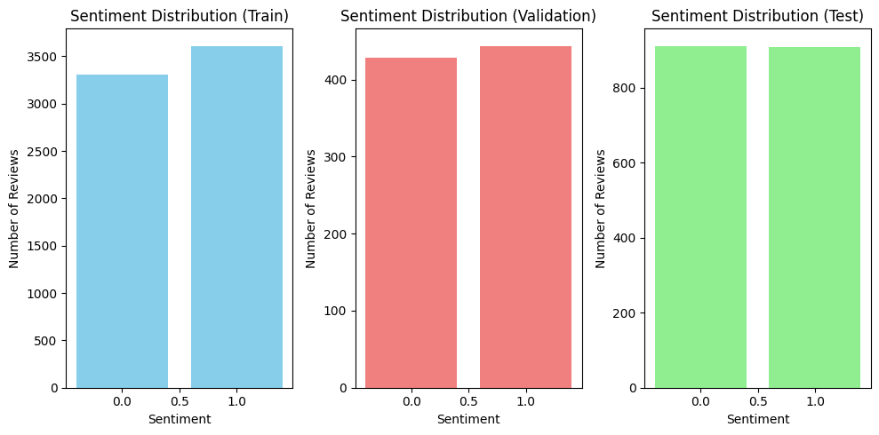

```
Descriptive statistics on review lengths:
```

|  | Mean | Median | IQR | Dataset |
| --- | --- | --- | --- | --- |
| 0 | 6.877890 | 7.0 | 5.0 | Train |
| 1 | 6.712156 | 6.0 | 5.0 | Validation |
| 2 | 6.408567 | 6.0 | 4.0 | Test |

```python
import matplotlib.pyplot as plt
import pandas as pd
import numpy as np

def plot_sentiment_distribution(dfs, names):
    fig, axes = plt.subplots(1, 3, figsize=(10, 5))
    colors = ['skyblue', 'lightcoral', 'lightgreen']  # Colors for train/val/test

    for i, (df, name) in enumerate(zip(dfs, names)):
        sentiment_counts = df['sentiment'].value_counts()
        axes[i].bar(sentiment_counts.index, sentiment_counts.values, color=colors[i])
        axes[i].set_title(f'Sentiment Distribution ({name})')
        axes[i].set_xlabel('Sentiment')
        axes[i].set_ylabel('Number of Reviews')
    plt.tight_layout()
    plt.show()

def calculate_review_stats(df, name):
    review_lengths = df['cleaned_review'].apply(lambda x: len(x.split()))
    mean_length = review_lengths.mean()
    median_length = review_lengths.median()
    q1 = review_lengths.quantile(0.25)
    q3 = review_lengths.quantile(0.75)
    iqr = q3 - q1
    return mean_length, median_length, iqr, name


def display_stats_table(stats_list):
    # Create a DataFrame for better visualization
    stats_df = pd.DataFrame(stats_list, columns=['Mean', 'Median', 'IQR', 'Dataset'])
    display(stats_df)


# Visualize sentiment distribution
plot_sentiment_distribution([train_df, val_df, test_df], ['Train', 'Validation', 'Test'])


# Calculate and display descriptive statistics on review lengths
review_stats = [calculate_review_stats(train_df, 'Train'),
               calculate_review_stats(val_df, 'Validation'),
               calculate_review_stats(test_df, 'Test')]

print('Descriptive statistics on review lengths:')
display_stats_table(review_stats)
```

2. **Text Characteristics**
   - Plot the 20 most frequent tokens per sentiment class.
   - Generate word clouds (or bar charts) highlighting key terms for each class.

```
Sentiment: 1
```

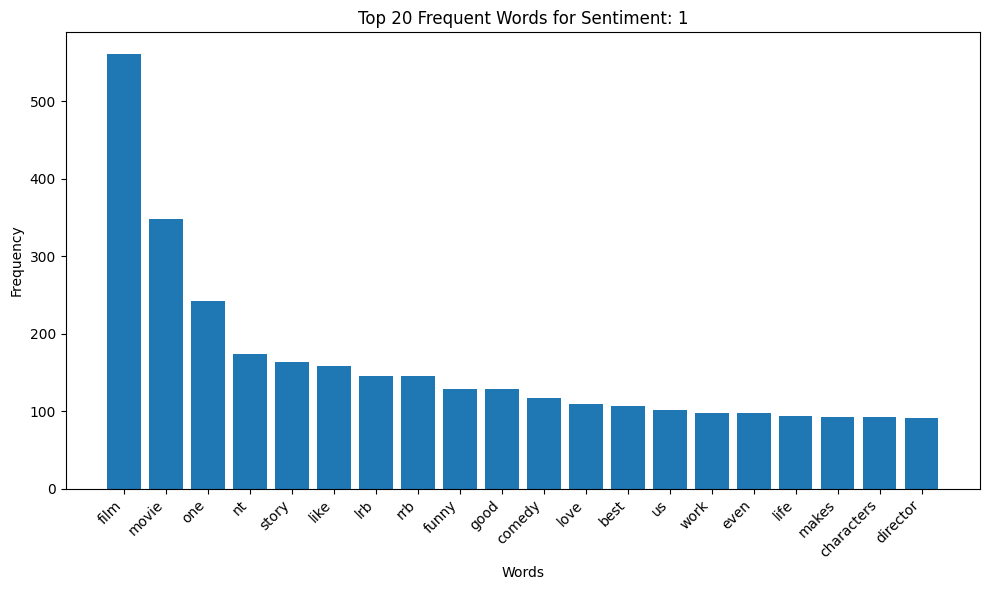

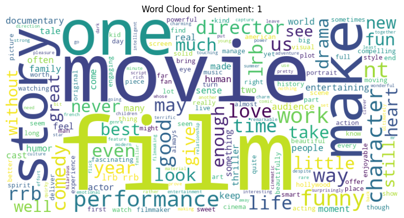

```
Sentiment: 0
```

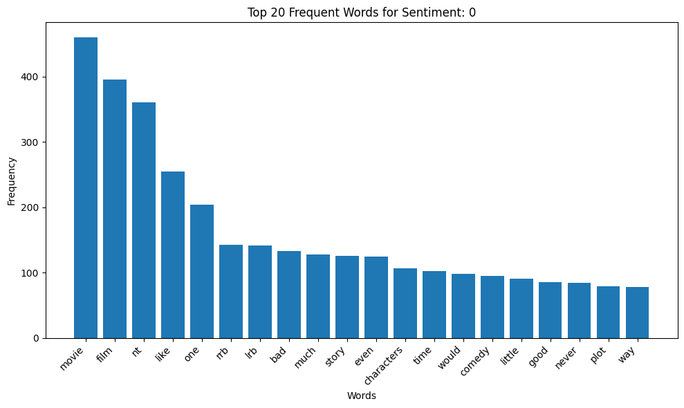

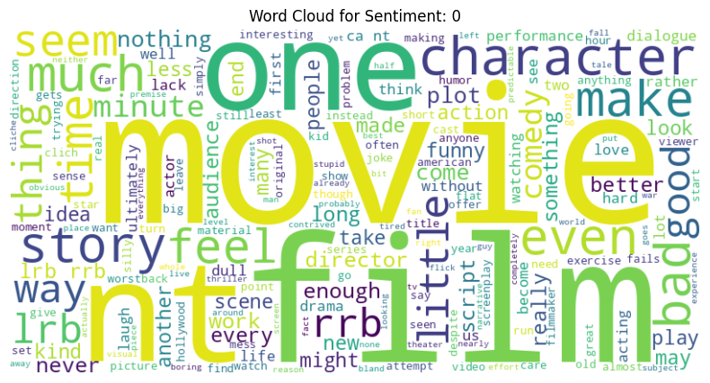

```python
from wordcloud import WordCloud
import matplotlib.pyplot as plt

def plot_frequent_tokens(df, sentiment_label, top_n=20):
    sentiment_reviews = df[df['sentiment'] == sentiment_label]['cleaned_review']
    all_text = ' '.join(sentiment_reviews)
    word_counts = Counter(all_text.split())
    most_common_words = word_counts.most_common(top_n)
    words, counts = zip(*most_common_words)

    plt.figure(figsize=(10, 6))
    plt.bar(words, counts)
    plt.xlabel("Words")
    plt.ylabel("Frequency")
    plt.title(f"Top {top_n} Frequent Words for Sentiment: {sentiment_label}")
    plt.xticks(rotation=45, ha='right')  # Rotate x-axis labels for better readability
    plt.tight_layout()
    plt.show()


def generate_wordcloud(df, sentiment_label):
    sentiment_reviews = df[df['sentiment'] == sentiment_label]['cleaned_review']
    all_text = ' '.join(sentiment_reviews)
    wordcloud = WordCloud(width=800, height=400, background_color='white').generate(all_text)
    plt.figure(figsize=(10, 5))
    plt.imshow(wordcloud, interpolation='bilinear')
    plt.axis("off")
    plt.title(f"Word Cloud for Sentiment: {sentiment_label}")
    plt.show()

for sentiment in train_df['sentiment'].unique():
    print(f"Sentiment: {sentiment}")
    plot_frequent_tokens(train_df, sentiment)
    generate_wordcloud(train_df, sentiment)
```

3. **Correlation Analysis**
   - Analyze whether review length correlates with sentiment.
   - Present findings numerically and with at least one visualization.

```
Mean Review Length(Character) by Sentiment:
```

| sentiment | review_length |
| --- | --- |
| 0 | 44.676435 |
| 1 | 48.988089 |

**dtype:** float64

```
Correlation coefficient between sentiment and review length(Character): 0.08372231600828023
```

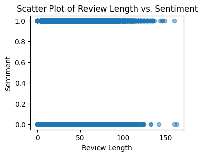

```python
import matplotlib.pyplot as plt

train_df['review_length'] = train_df['cleaned_review'].apply(len)
mean_review_length_by_sentiment = train_df.groupby('sentiment')['review_length'].mean()

print("Mean Review Length(Character) by Sentiment:")
display(mean_review_length_by_sentiment)


correlation = train_df['sentiment'].corr(train_df['review_length'])
print(f"\nCorrelation coefficient between sentiment and review length(Character): {correlation}")

plt.figure(figsize=(4, 3))
plt.scatter(train_df['review_length'], train_df['sentiment'], alpha=0.5)  # Adjust alpha for transparency
plt.xlabel("Review Length")
plt.ylabel("Sentiment")
plt.title("Scatter Plot of Review Length vs. Sentiment")
plt.show()
```

## Part 3 – Baseline Traditional Models

1. **Logistic Regression & SVM**
   - Train at least two linear models on your TF-IDF features.
   - Use cross-validation (≥ 5 folds) on the training set to tune at least one hyperparameter.

```python
from sklearn.linear_model import LogisticRegression
from sklearn.model_selection import GridSearchCV, cross_val_score
from sklearn.metrics import accuracy_score, precision_score, recall_score, f1_score, roc_auc_score

logreg_model = LogisticRegression(solver='liblinear')

param_grid = {'C': [0.1, 1, 10]} # penalty strength!
grid_search = GridSearchCV(logreg_model, param_grid, cv=5, scoring='accuracy')
grid_search.fit(DTM_train, train_df['sentiment'])

print("Best hyperparameters:", grid_search.best_params_)
print("Best cross-validation score:", grid_search.best_score_)

best_logreg_model = grid_search.best_estimator_
y_pred_logreg = best_logreg_model.predict(DTM_test)
y_prob_logreg = best_logreg_model.predict_proba(DTM_test)[:, 1]  # Probability estimates for positive class

# Evaluate the model
print('Test set evaluation:')
accuracy_logreg = accuracy_score(test_df['sentiment'], y_pred_logreg)
precision_logreg = precision_score(test_df['sentiment'], y_pred_logreg)
recall_logreg = recall_score(test_df['sentiment'], y_pred_logreg)
f1_logreg = f1_score(test_df['sentiment'], y_pred_logreg)
roc_auc_logreg = roc_auc_score(test_df['sentiment'], y_prob_logreg)


print(f"Accuracy: {accuracy_logreg}")
print(f"Precision: {precision_logreg}")
print(f"Recall: {recall_logreg}")
print(f"F1-score: {f1_logreg}")
print(f"ROC AUC: {roc_auc_logreg}")
```

```
Best hyperparameters: {'C': 1}
Best cross-validation score: 0.7625722543352601
Test set evaluation:
Accuracy: 0.7688083470620538
Precision: 0.75
Recall: 0.8052805280528053
F1-score: 0.776657824933687
ROC AUC: 0.8565140505278599
```

```python
from sklearn.svm import LinearSVC
svm_model = LinearSVC()
param_grid_svm = {'C': [0.1, 1, 10]}
grid_search_svm = GridSearchCV(svm_model, param_grid_svm, cv=5, scoring='accuracy')
grid_search_svm.fit(DTM_train, train_df['sentiment'])
print("Best hyperparameters (SVM):", grid_search_svm.best_params_)
print("Best cross-validation score (SVM):", grid_search_svm.best_score_)
best_svm_model = grid_search_svm.best_estimator_
y_pred_svm = best_svm_model.predict(DTM_test)

print('Test set evaluation (SVM):')
accuracy_svm = accuracy_score(test_df['sentiment'], y_pred_svm)
precision_svm = precision_score(test_df['sentiment'], y_pred_svm)
recall_svm = recall_score(test_df['sentiment'], y_pred_svm)
f1_svm = f1_score(test_df['sentiment'], y_pred_svm)

print(f"Accuracy: {accuracy_svm}")
print(f"Precision: {precision_svm}")
print(f"Recall: {recall_svm}")
print(f"F1-score: {f1_svm}")
```

```
Best hyperparameters (SVM): {'C': 0.1}
Best cross-validation score (SVM): 0.7593930635838151
Test set evaluation (SVM):
Accuracy: 0.7682591982427238
Precision: 0.7487231869254342
Recall: 0.8063806380638063
F1-score: 0.7764830508474576
```

2. **Random Forest & Gradient Boosting**
   - Train two tree-based models (e.g., Random Forest, XGBoost) on the same features.
   - Report feature-importance for each and discuss any notable tokens.

```python
from sklearn.ensemble import RandomForestClassifier

rf_model = RandomForestClassifier(random_state=42)
param_grid_rf = {'n_estimators': [50, 100, 200]}
grid_search_rf = GridSearchCV(rf_model, param_grid_rf, cv=5, scoring='accuracy')
grid_search_rf.fit(DTM_train, train_df['sentiment'])

print("Best hyperparameters (RF):", grid_search_rf.best_params_)
print("Best cross-validation score (RF):", grid_search_rf.best_score_)

best_rf_model = grid_search_rf.best_estimator_
y_pred_rf = best_rf_model.predict(DTM_test)

print('Test set evaluation (RF):')
accuracy_rf = accuracy_score(test_df['sentiment'], y_pred_rf)
precision_rf = precision_score(test_df['sentiment'], y_pred_rf)
recall_rf = recall_score(test_df['sentiment'], y_pred_rf)
f1_rf = f1_score(test_df['sentiment'], y_pred_rf)

print(f"Accuracy: {accuracy_rf}")
print(f"Precision: {precision_rf}")
print(f"Recall: {recall_rf}")
print(f"F1-score: {f1_rf}")

# Feature Importance
feature_importances = best_rf_model.feature_importances_
feature_names = vectorizer.get_feature_names_out()
important_features = sorted(zip(feature_names, feature_importances), key=lambda x: x[1], reverse=True)[:20]  # Top 20
print("\nTop 20 important features (RF):")
for feature, importance in important_features:
    print(f"{feature}: {importance}")
```

```
Best hyperparameters (RF): {'n_estimators': 200}
Best cross-validation score (RF): 0.7228323699421966
Test set evaluation (RF):
Accuracy: 0.7369577155409116
Precision: 0.7471264367816092
Recall: 0.7150715071507151
F1-score: 0.7307476110174255

Top 20 important features (RF):
nt: 0.014522607902200843
bad: 0.01070292439995653
movie: 0.009647999440329333
film: 0.009420734669869752
like: 0.007735351966915921
one: 0.005789006758601725
best: 0.005538576114976785
funny: 0.005453396955786
love: 0.004842875429901976
fun: 0.004695015670744232
nothing: 0.004674659396157886
minutes: 0.004260572260710591
dull: 0.004235758148000583
much: 0.00418083594375567
would: 0.004051072309384483
performances: 0.003952836517803023
plot: 0.003912795091904523
entertaining: 0.003825195670106315
worst: 0.0036926100912025583
good: 0.0035388891127859368
```

```python
import xgboost as xgb
from sklearn.metrics import accuracy_score, precision_score, recall_score, f1_score

xgb_model = xgb.XGBClassifier(random_state=42)
param_grid_xgb = {'n_estimators': [50, 100, 200]}
grid_search_xgb = GridSearchCV(xgb_model, param_grid_xgb, cv=5, scoring='accuracy')
grid_search_xgb.fit(DTM_train, train_df['sentiment'])

print("Best hyperparameters (XGBoost):", grid_search_xgb.best_params_)
print("Best cross-validation score (XGBoost):", grid_search_xgb.best_score_)

best_xgb_model = grid_search_xgb.best_estimator_
y_pred_xgb = best_xgb_model.predict(DTM_test)

print('Test set evaluation (XGBoost):')
accuracy_xgb = accuracy_score(test_df['sentiment'], y_pred_xgb)
precision_xgb = precision_score(test_df['sentiment'], y_pred_xgb)
recall_xgb = recall_score(test_df['sentiment'], y_pred_xgb)
f1_xgb = f1_score(test_df['sentiment'], y_pred_xgb)

print(f"Accuracy: {accuracy_xgb}")
print(f"Precision: {precision_xgb}")
print(f"Recall: {recall_xgb}")
print(f"F1-score: {f1_xgb}")

feature_importances_xgb = best_xgb_model.feature_importances_
feature_names_xgb = vectorizer.get_feature_names_out()
important_features_xgb = sorted(zip(feature_names_xgb, feature_importances_xgb), key=lambda x: x[1], reverse=True)[:20]
print("\nTop 20 important features (XGBoost):")
for feature, importance in important_features_xgb:
    print(f"{feature}: {importance}")
```

```
Best hyperparameters (XGBoost): {'n_estimators': 200}
Best cross-validation score (XGBoost): 0.7079479768786128
Test set evaluation (XGBoost):
Accuracy: 0.7160900604063701
Precision: 0.6902912621359223
Recall: 0.7821782178217822
F1-score: 0.7333677153171738

Top 20 important features (XGBoost):
minutes: 0.005952008534222841
heart: 0.005905953235924244
less: 0.00522091006860137
beautifully: 0.004898638464510441
performances: 0.004896671511232853
powerful: 0.004737173672765493
mess: 0.00467350147664547
flat: 0.004494518972933292
worst: 0.0043777357786893845
portrait: 0.004175951238721609
solid: 0.004173459950834513
world: 0.004050535149872303
rare: 0.004008800722658634
nothing: 0.003920925315469503
life: 0.0038345037028193474
tale: 0.003791130380704999
would: 0.0037205552216619253
action: 0.0036989913787692785
problem: 0.0036798857618123293
star: 0.0036718028131872416
```

3. **Evaluation Metrics**
   - Compute accuracy, precision, recall, F1-score, and ROC-AUC on the **held-out test set**.
   - Present all results in a single comparison table.

```python
results = {
    'Model': ['Logistic Regression', 'SVM', 'Random Forest', 'XGBoost'],
    'Accuracy': [accuracy_logreg, accuracy_svm, accuracy_rf, accuracy_xgb],
    'Precision': [precision_logreg, precision_svm, precision_rf, precision_xgb],
    'Recall': [recall_logreg, recall_svm, recall_rf, recall_xgb],
    'F1-score': [f1_logreg, f1_svm, f1_rf, f1_xgb],
    'ROC AUC': [roc_auc_logreg, np.nan, np.nan, np.nan] # ROC AUC not available for SVM, RF and XGB in this code
}
results_df = pd.DataFrame(results)
display(results_df)
```

|  | Model | Accuracy | Precision | Recall | F1-score | ROC AUC |
| --- | --- | --- | --- | --- | --- | --- |
| 0 | Logistic Regression | 0.768808 | 0.750000 | 0.805281 | 0.776658 | 0.856514 |
| 1 | SVM | 0.768259 | 0.748723 | 0.806381 | 0.776483 | NaN |
| 2 | Random Forest | 0.736958 | 0.747126 | 0.715072 | 0.730748 | NaN |
| 3 | XGBoost | 0.716090 | 0.690291 | 0.782178 | 0.733368 | NaN |

## Part 4 – Neural Network Models

1. **Simple Feed-Forward**
   - Build an embedding layer + a dense MLP classifier.
   - Ensure you freeze vs. unfreeze embeddings in separate runs.

```
Frozen Embeddings - Test Accuracy: 0.4991762638092041
Unfrozen Embeddings - Test Accuracy: 0.7342119812965393
```

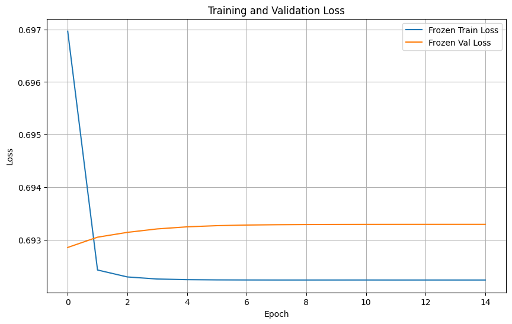

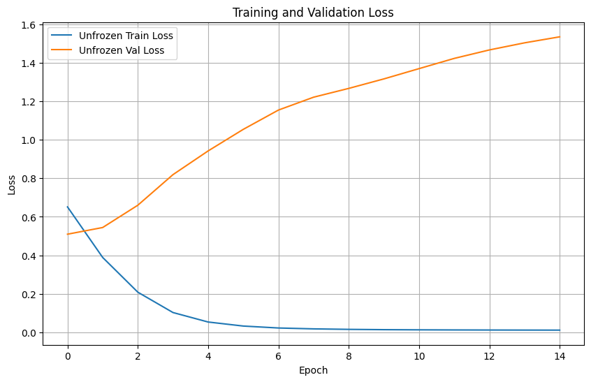

```python
import tensorflow as tf
from tensorflow.keras.models import Sequential
from tensorflow.keras.layers import Embedding, Dense, Flatten

# Define the vocabulary size and embedding dimension
vocab_size = len(tokenizer.word_index) + 1  # +1 for padding token
embedding_dim = 100  # Adjust as needed

# Build the model
def build_mlp_model(freeze_embeddings=False):
    model = Sequential()
    model.add(Embedding(vocab_size, embedding_dim, input_length=max_sequence_length))
    if freeze_embeddings:
        model.layers[0].trainable = False  # Freeze embedding layer weights

    model.add(Flatten())  # Flatten the embedding sequences
    model.add(Dense(128, activation='relu'))
    model.add(Dense(1, activation='sigmoid'))  # Sigmoid for binary classification

    model.compile(optimizer='adam', loss='binary_crossentropy', metrics=['accuracy'])
    return model

frozen_model = build_mlp_model(freeze_embeddings=True)
unfrozen_model = build_mlp_model(freeze_embeddings=False)

frozen_history = frozen_model.fit(X_train_seq, train_df['sentiment'],
                                  epochs=15, validation_data=(X_val_seq, val_df['sentiment']), verbose=0)
frozen_loss, frozen_accuracy = frozen_model.evaluate(X_test_seq, test_df['sentiment'], verbose=0)
print(f"Frozen Embeddings - Test Accuracy: {frozen_accuracy}")

unfrozen_history = unfrozen_model.fit(X_train_seq, train_df['sentiment'],
                                      epochs=15, validation_data=(X_val_seq, val_df['sentiment']), verbose=0)
unfrozen_loss, unfrozen_accuracy = unfrozen_model.evaluate(X_test_seq, test_df['sentiment'], verbose=0)
print(f"Unfrozen Embeddings - Test Accuracy: {unfrozen_accuracy}")

plt.figure(figsize=(10,6))
plt.plot(frozen_history.history['loss'], label='Frozen Train Loss')
plt.plot(frozen_history.history['val_loss'], label='Frozen Val Loss')
plt.title('Training and Validation Loss')
plt.xlabel('Epoch')
plt.ylabel('Loss')
plt.legend()
plt.grid(True)
plt.show()


plt.figure(figsize=(10,6))
plt.plot(unfrozen_history.history['loss'], label='Unfrozen Train Loss')
plt.plot(unfrozen_history.history['val_loss'], label='Unfrozen Val Loss')
plt.title('Training and Validation Loss')
plt.xlabel('Epoch')
plt.ylabel('Loss')
plt.legend()
plt.grid(True)
plt.show()
```

2. **Convolutional Text Classifier**
   - Implement a 1D-CNN architecture (Conv + Pooling) for sequence data.
   - Justify your choice of kernel sizes and number of filters.

```
CNN - Test Accuracy: 0.6919274926185608
```

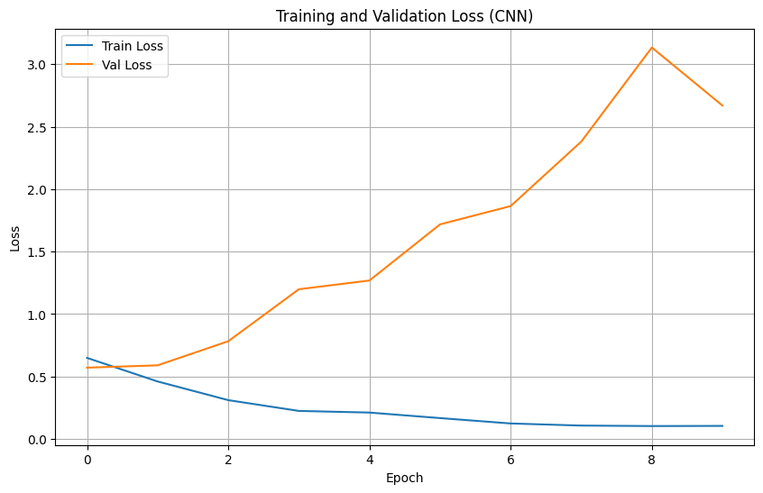

```python
from tensorflow.keras.layers import Conv1D, MaxPooling1D

def build_cnn_model():
    model = Sequential()
    model.add(Embedding(vocab_size, embedding_dim, input_length=max_sequence_length))

    # Convolutional layers with different kernel sizes
    model.add(Conv1D(filters=64, kernel_size=3, activation='relu')) # For capturing short-range dependencies
    model.add(MaxPooling1D(pool_size=2))
    model.add(Conv1D(filters=128, kernel_size=5, activation='relu')) # For capturing medium-range dependencies
    model.add(MaxPooling1D(pool_size=2))
    model.add(Conv1D(filters=256, kernel_size=7, activation='relu')) # For capturing long-range dependencies
    model.add(MaxPooling1D(pool_size=2))

    model.add(Flatten())
    model.add(Dense(128, activation='relu'))
    model.add(Dense(1, activation='sigmoid'))  # Output layer

    model.compile(optimizer='adam', loss='binary_crossentropy', metrics=['accuracy'])
    return model

cnn_model = build_cnn_model()

cnn_history = cnn_model.fit(X_train_seq, train_df['sentiment'], epochs=10, validation_data=(X_val_seq, val_df['sentiment']), verbose=0)

cnn_loss, cnn_accuracy = cnn_model.evaluate(X_test_seq, test_df['sentiment'], verbose=0)
print(f"CNN - Test Accuracy: {cnn_accuracy}")

plt.figure(figsize=(10, 6))
plt.plot(cnn_history.history['loss'], label='Train Loss')
plt.plot(cnn_history.history['val_loss'], label='Val Loss')
plt.title('Training and Validation Loss (CNN)')
plt.xlabel('Epoch')
plt.ylabel('Loss')
plt.legend()
plt.grid(True)
plt.show()
```

3. **Recurrent Model (Optional)**
   - (Stretch) Add an RNN or Bi-LSTM layer and compare performance/time vs. CNN.

```
217/217 ━━━━━━━━━━━━━━━━━━━━ 6s 12ms/step - accuracy: 0.5985 - loss: 0.6526 - val_accuracy: 0.7649 - val_loss: 0.4957
217/217 ━━━━━━━━━━━━━━━━━━━━ 2s 10ms/step - accuracy: 0.8168 - loss: 0.3996 - val_accuracy: 0.7534 - val_loss: 0.5321
217/217 ━━━━━━━━━━━━━━━━━━━━ 2s 10ms/step - accuracy: 0.8602 - loss: 0.3336 - val_accuracy: 0.7557 - val_loss: 0.6206
217/217 ━━━━━━━━━━━━━━━━━━━━ 2s 10ms/step - accuracy: 0.8959 - loss: 0.2629 - val_accuracy: 0.7557 - val_loss: 0.7370
217/217 ━━━━━━━━━━━━━━━━━━━━ 2s 10ms/step - accuracy: 0.9224 - loss: 0.2038 - val_accuracy: 0.7500 - val_loss: 0.8930
217/217 ━━━━━━━━━━━━━━━━━━━━ 2s 10ms/step - accuracy: 0.9470 - loss: 0.1470 - val_accuracy: 0.7534 - val_loss: 0.9943
217/217 ━━━━━━━━━━━━━━━━━━━━ 2s 10ms/step - accuracy: 0.9578 - loss: 0.1121 - val_accuracy: 0.7385 - val_loss: 1.0956
217/217 ━━━━━━━━━━━━━━━━━━━━ 2s 10ms/step - accuracy: 0.9551 - loss: 0.1099 - val_accuracy: 0.7592 - val_loss: 1.1077
217/217 ━━━━━━━━━━━━━━━━━━━━ 2s 10ms/step - accuracy: 0.9602 - loss: 0.1011 - val_accuracy: 0.7557 - val_loss: 1.1834
217/217 ━━━━━━━━━━━━━━━━━━━━ 2s 10ms/step - accuracy: 0.9680 - loss: 0.0794 - val_accuracy: 0.7534 - val_loss: 1.3139
Bi-LSTM - Test Accuracy: 0.749588131904602
```

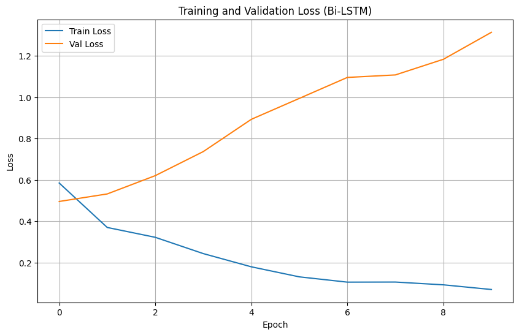

```python
from tensorflow.keras.layers import LSTM, Bidirectional

def build_bilstm_model():
    model = Sequential()
    model.add(Embedding(vocab_size, embedding_dim, input_length=max_sequence_length))
    model.add(Bidirectional(LSTM(64)))  # Bi-LSTM layer
    model.add(Dense(1, activation='sigmoid'))
    model.compile(optimizer='adam', loss='binary_crossentropy', metrics=['accuracy'])
    return model

bilstm_model = build_bilstm_model()
bilstm_history = bilstm_model.fit(X_train_seq, train_df['sentiment'], epochs=10,
                                 validation_data=(X_val_seq, val_df['sentiment']))

bilstm_loss, bilstm_accuracy = bilstm_model.evaluate(X_test_seq, test_df['sentiment'], verbose=0)
print(f"Bi-LSTM - Test Accuracy: {bilstm_accuracy}")

plt.figure(figsize=(10, 6))
plt.plot(bilstm_history.history['loss'], label='Train Loss')
plt.plot(bilstm_history.history['val_loss'], label='Val Loss')
plt.title('Training and Validation Loss (Bi-LSTM)')
plt.xlabel('Epoch')
plt.ylabel('Loss')
plt.legend()
plt.grid(True)
plt.show()
```

## Part 5 – Transfer Learning & Advanced Architectures

1. **Pre-trained Embeddings**
   - Retrain one network using pre-trained GloVe (or FastText) embeddings.
   - Compare results against your from-scratch embedding runs.

```
!wget http://nlp.stanford.edu/data/glove.6B.zip
!unzip glove.6B.zip
```

```
217/217 ━━━━━━━━━━━━━━━━━━━━ 2s 5ms/step - accuracy: 0.6303 - loss: 0.6358 - val_accuracy: 0.7317 - val_loss: 0.5377
217/217 ━━━━━━━━━━━━━━━━━━━━ 1s 2ms/step - accuracy: 0.7616 - loss: 0.4891 - val_accuracy: 0.7225 - val_loss: 0.5380
217/217 ━━━━━━━━━━━━━━━━━━━━ 1s 2ms/step - accuracy: 0.8129 - loss: 0.4087 - val_accuracy: 0.7236 - val_loss: 0.5569
217/217 ━━━━━━━━━━━━━━━━━━━━ 1s 2ms/step - accuracy: 0.8673 - loss: 0.3273 - val_accuracy: 0.7271 - val_loss: 0.5948
217/217 ━━━━━━━━━━━━━━━━━━━━ 1s 2ms/step - accuracy: 0.9037 - loss: 0.2534 - val_accuracy: 0.7190 - val_loss: 0.6415
217/217 ━━━━━━━━━━━━━━━━━━━━ 1s 2ms/step - accuracy: 0.9335 - loss: 0.1914 - val_accuracy: 0.7076 - val_loss: 0.7153
217/217 ━━━━━━━━━━━━━━━━━━━━ 1s 2ms/step - accuracy: 0.9569 - loss: 0.1481 - val_accuracy: 0.6927 - val_loss: 0.8548
217/217 ━━━━━━━━━━━━━━━━━━━━ 1s 2ms/step - accuracy: 0.9619 - loss: 0.1253 - val_accuracy: 0.6789 - val_loss: 1.1136
217/217 ━━━━━━━━━━━━━━━━━━━━ 1s 2ms/step - accuracy: 0.9597 - loss: 0.1191 - val_accuracy: 0.6904 - val_loss: 1.0215
217/217 ━━━━━━━━━━━━━━━━━━━━ 1s 2ms/step - accuracy: 0.9529 - loss: 0.1260 - val_accuracy: 0.6800 - val_loss: 1.0582
GloVe Embeddings - Test Accuracy: 0.6589785814285278
```

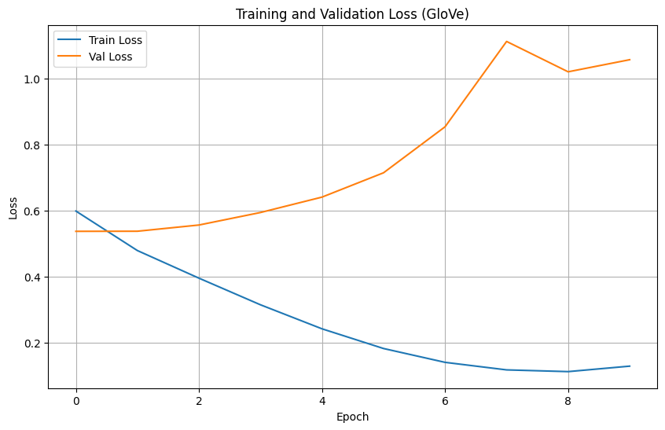

```python
glove_embeddings = {}
with open('glove.6B.100d.txt', 'r', encoding='utf-8') as f:
    for line in f:
        values = line.split()
        word = values[0]
        vector = np.asarray(values[1:], dtype='float32')
        glove_embeddings[word] = vector

embedding_matrix = np.zeros((vocab_size, embedding_dim))
for word, i in tokenizer.word_index.items():
    embedding_vector = glove_embeddings.get(word)
    if embedding_vector is not None:
        embedding_matrix[i] = embedding_vector

def build_glove_model():
    model = Sequential()
    model.add(Embedding(vocab_size, embedding_dim, weights=[embedding_matrix], input_length=max_sequence_length, trainable=False)) # Set trainable=False to freeze
    model.add(Flatten())
    model.add(Dense(128, activation='relu'))
    model.add(Dense(1, activation='sigmoid'))
    model.compile(optimizer='adam', loss='binary_crossentropy', metrics=['accuracy'])
    return model

glove_model = build_glove_model()
glove_history = glove_model.fit(X_train_seq, train_df['sentiment'], epochs=10,
                                validation_data=(X_val_seq, val_df['sentiment']))

glove_loss, glove_accuracy = glove_model.evaluate(X_test_seq, test_df['sentiment'], verbose=0)
print(f"GloVe Embeddings - Test Accuracy: {glove_accuracy}")

plt.figure(figsize=(10, 6))
plt.plot(glove_history.history['loss'], label='Train Loss')
plt.plot(glove_history.history['val_loss'], label='Val Loss')
plt.title('Training and Validation Loss (GloVe)')
plt.xlabel('Epoch')
plt.ylabel('Loss')
plt.legend()
plt.grid(True)
plt.show()
```

2. **Transformer Fine-Tuning**
   - Fine-tune a BERT-family model on the training data.
   - Clearly outline your training hyperparameters (learning rate, batch size, epochs).

[output not shown]

```
Some weights of BertForSequenceClassification were not initialized from the model checkpoint at bert-base-uncased and are newly initialized: ['classifier.bias', 'classifier.weight']
You should probably TRAIN this model on a down-stream task to be able to use it for predictions and inference.
```

[1299/1299 09:48, Epoch 3/3]

| Epoch | Training Loss | Validation Loss | Accuracy |
| --- | --- | --- | --- |
| 1 | 0.545600 | 0.551126 | 0.700688 |
| 2 | 0.420700 | 0.471463 | 0.801606 |
| 3 | 0.098200 | 0.691300 | 0.795872 |

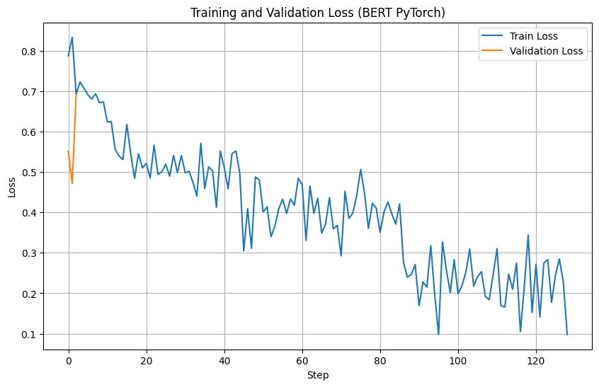

```python
import torch
from transformers import BertTokenizer, BertForSequenceClassification, Trainer, TrainingArguments
from datasets import Dataset
import matplotlib.pyplot as plt

# Load tokenizer and model (PyTorch version)
model_name = "bert-base-uncased"
tokenizer = BertTokenizer.from_pretrained(model_name)
model = BertForSequenceClassification.from_pretrained(model_name, num_labels=2)

def tokenize_function(examples):
    return tokenizer(examples["cleaned_review"], padding="max_length", truncation=True, max_length=128)

train_dataset = Dataset.from_pandas(train_df)
val_dataset = Dataset.from_pandas(val_df)

train_dataset = train_dataset.rename_column("sentiment", "labels")
val_dataset = val_dataset.rename_column("sentiment", "labels")

tokenized_train = train_dataset.map(tokenize_function, batched=True)
tokenized_val = val_dataset.map(tokenize_function, batched=True)

tokenized_train.set_format('torch', columns=['input_ids', 'attention_mask', 'labels'])
tokenized_val.set_format('torch', columns=['input_ids', 'attention_mask', 'labels'])

training_args = TrainingArguments(
    output_dir="./results",
    num_train_epochs=3,
    per_device_train_batch_size=16,
    per_device_eval_batch_size=64,
    warmup_steps=500,
    weight_decay=0.01,
    logging_dir='./logs',
    logging_steps=10,
    eval_strategy="epoch",
    save_strategy="epoch",
    load_best_model_at_end=True,
    metric_for_best_model="accuracy",
    report_to="none"
)

def compute_metrics(pred):
    logits, labels = pred
    predictions = np.argmax(logits, axis=-1)
    acc = accuracy_score(labels, predictions)
    return {"accuracy": acc}

trainer = Trainer(
    model=model,
    args=training_args,
    train_dataset=tokenized_train,
    eval_dataset=tokenized_val,
    compute_metrics=compute_metrics
)

train_result = trainer.train()
metrics = train_result.metrics
logs = trainer.state.log_history

#plot
train_losses = [log['loss'] for log in logs if 'loss' in log]
eval_losses = [log['eval_loss'] for log in logs if 'eval_loss' in log]

plt.figure(figsize=(10, 6))
plt.plot(train_losses, label='Train Loss')
plt.plot(eval_losses, label='Validation Loss')
plt.title('Training and Validation Loss (BERT PyTorch)')
plt.xlabel('Step')
plt.ylabel('Loss')
plt.legend()
plt.grid(True)
plt.show()
```

```python
test_dataset = Dataset.from_pandas(test_df)
test_dataset = test_dataset.rename_column("sentiment", "labels")
tokenized_test = test_dataset.map(tokenize_function, batched=True)
tokenized_test.set_format('torch', columns=['input_ids', 'attention_mask', 'labels'])
test_results = trainer.predict(tokenized_test)
print(test_results.metrics)

accuracy_BERT = test_results.metrics['test_accuracy']
```

```
{'test_loss': 0.4585579037666321, 'test_accuracy': 0.8083470620538166, 'test_runtime': 12.2277, 'test_samples_per_second': 148.924, 'test_steps_per_second': 2.372}
```

```python
y_BERT = np.argmax(test_results.predictions, axis=1)
y_BERT
```

```
array([0, 1, 0, ..., 0, 0, 0])
```

Hyperparameters for BERT fine-tuning:

Learning rate: 5e-5 (This is a common starting point for BERT)  
Batch size: 16 (A balance between memory usage and training speed)  
Epochs: 3 (Sufficient for fine-tuning, especially with a pre-trained model)

```python
trainer.save_model("./trained_model/BERT1")
```

## Part 6 – Hyperparameter Optimization

1. **Search Strategy**
   - Use a library (e.g., Keras Tuner, Optuna) to optimize at least two hyperparameters of one deep model.
   - Describe your search space and stopping criteria.

```python
import keras_tuner as kt
from tensorflow.keras.layers import Embedding, Conv1D, MaxPooling1D, Flatten, Dense
from tensorflow.keras.models import Sequential
import tensorflow as tf

def build_model(hp):
    model = Sequential()
    model.add(Embedding(vocab_size, embedding_dim, input_length=max_sequence_length))

    # Tune the number of filters in the first convolutional layer
    filters1 = hp.Int('filters1', min_value=32, max_value=64, step=32)
    kernel_size1 = hp.Choice('kernel_size1', values=[3, 5])
    model.add(Conv1D(filters=filters1, kernel_size=kernel_size1, activation='relu'))
    model.add(MaxPooling1D(pool_size=2))

    # Tune the kernel size of the second convolutional layer
    filters2 = hp.Int('filters2', min_value=64, max_value=128, step=32)
    kernel_size2 = hp.Choice('kernel_size2', values=[5, 7])
    model.add(Conv1D(filters=filters2, kernel_size=kernel_size2, activation='relu'))
    model.add(MaxPooling1D(pool_size=2))

    model.add(Conv1D(filters=256, kernel_size=7, activation='relu'))
    model.add(MaxPooling1D(pool_size=2))
    model.add(Flatten())
    model.add(Dense(128, activation='relu'))
    model.add(Dense(1, activation='sigmoid'))

    # Fix the learning rate manually (NOT tuned)
    optimizer = tf.keras.optimizers.Adam(learning_rate=1e-3)

    model.compile(optimizer=optimizer, loss='binary_crossentropy', metrics=['accuracy'])
    return model

# Tuner setup
tuner = kt.Hyperband(
    build_model,
    objective='val_accuracy',
    max_epochs=30,
    factor=3,
    directory='my_dir',
    project_name='intro_to_kt_v8'
)

# Early stopping
stop_early = tf.keras.callbacks.EarlyStopping(monitor='val_loss', patience=7)

# Search best hyperparameters
tuner.search(X_train_seq, train_df['sentiment'], epochs=50, validation_data=(X_val_seq, val_df['sentiment']), callbacks=[stop_early])

# Get best hyperparameters
best_hps = tuner.get_best_hyperparameters(num_trials=1)[0]

print(f"""
The hyperparameter search is complete.
The optimal number of filters in the first convolutional layer is {best_hps.get('filters1')}.
The optimal kernel size for the first convolutional layer is {best_hps.get('kernel_size1')}.
The optimal kernel size for the second convolutional layer is {best_hps.get('kernel_size2')}.
The optimal number of filters in the second convolutional layer is {best_hps.get('filters2')}.
""")
```

```
Trial 22 Complete [00h 00m 09s]
val_accuracy: 0.6307339668273926

Best val_accuracy So Far: 0.7614678740501404
Total elapsed time: 00h 03m 10s

The hyperparameter search is complete.
The optimal number of filters in the first convolutional layer is 32.
The optimal kernel size for the first convolutional layer is 5.
The optimal kernel size for the second convolutional layer is 5.
The optimal number of filters in the second convolutional layer is 128.
```

```
217/217 ━━━━━━━━━━━━━━━━━━━━ 5s 11ms/step - accuracy: 0.5583 - loss: 0.6697 - val_accuracy: 0.7534 - val_loss: 0.5188
217/217 ━━━━━━━━━━━━━━━━━━━━ 1s 4ms/step - accuracy: 0.7925 - loss: 0.4414 - val_accuracy: 0.7523 - val_loss: 0.6348
217/217 ━━━━━━━━━━━━━━━━━━━━ 1s 3ms/step - accuracy: 0.8921 - loss: 0.2549 - val_accuracy: 0.7557 - val_loss: 0.9410
217/217 ━━━━━━━━━━━━━━━━━━━━ 1s 3ms/step - accuracy: 0.9424 - loss: 0.1366 - val_accuracy: 0.7213 - val_loss: 1.3350
217/217 ━━━━━━━━━━━━━━━━━━━━ 1s 3ms/step - accuracy: 0.9699 - loss: 0.0810 - val_accuracy: 0.7305 - val_loss: 1.6233
217/217 ━━━━━━━━━━━━━━━━━━━━ 1s 3ms/step - accuracy: 0.9667 - loss: 0.0868 - val_accuracy: 0.7271 - val_loss: 1.5495
217/217 ━━━━━━━━━━━━━━━━━━━━ 1s 4ms/step - accuracy: 0.9669 - loss: 0.0945 - val_accuracy: 0.7397 - val_loss: 1.7039
217/217 ━━━━━━━━━━━━━━━━━━━━ 1s 4ms/step - accuracy: 0.9771 - loss: 0.0539 - val_accuracy: 0.7282 - val_loss: 2.0126
217/217 ━━━━━━━━━━━━━━━━━━━━ 1s 3ms/step - accuracy: 0.9881 - loss: 0.0292 - val_accuracy: 0.7317 - val_loss: 2.2882
217/217 ━━━━━━━━━━━━━━━━━━━━ 1s 3ms/step - accuracy: 0.9922 - loss: 0.0159 - val_accuracy: 0.7271 - val_loss: 2.6151
Fine Tuned CNN model's Test Accuracy: 0.7419000267982483
```

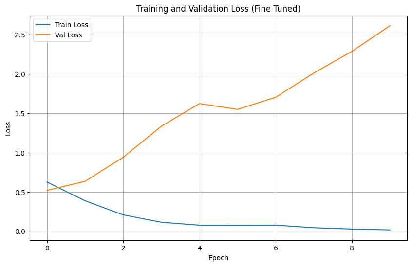

```python
model = tuner.hypermodel.build(best_hps)
stop_early = tf.keras.callbacks.EarlyStopping(monitor='val_accuracy', patience=7)
history = model.fit(X_train_seq, train_df['sentiment'], epochs=50, validation_data=(X_val_seq, val_df['sentiment']), callbacks=[stop_early])

loss_ft, accuracy_ft = model.evaluate(X_test_seq, test_df['sentiment'], verbose=0)
print(f"Fine Tuned CNN model's Test Accuracy: {accuracy_ft}")

plt.figure(figsize=(10, 6))
plt.plot(history.history['loss'], label='Train Loss')
plt.plot(history.history['val_loss'], label='Val Loss')
plt.title('Training and Validation Loss (Fine Tuned)')
plt.xlabel('Epoch')
plt.ylabel('Loss')
plt.legend()
plt.grid(True)
plt.show()
```

2. **Results Analysis**
   - Report the best hyperparameter configuration found.
   - Plot validation-loss (or metric) vs. trials to illustrate tuning behavior.

```python
print(f"""
The hyperparameter search is complete.
The optimal number of filters in the first convolutional layer is {best_hps.get('filters1')}.
The optimal kernel size for the first convolutional layer is {best_hps.get('kernel_size1')}.
The optimal kernel size for the second convolutional layer is {best_hps.get('kernel_size2')}.
The optimal number of filters in the second convolutional layer is {best_hps.get('filters2')}.
""")

print(f"Fine Tuned CNN model's Test Accuracy: {accuracy_ft}")
```

```
The hyperparameter search is complete.
The optimal number of filters in the first convolutional layer is 32.
The optimal kernel size for the first convolutional layer is 5.
The optimal kernel size for the second convolutional layer is 5.
The optimal number of filters in the second convolutional layer is 128.

Fine Tuned CNN model's Test Accuracy: 0.7419000267982483
```

All the best hyperparameters are shown above. The test reults are also shown above. (Both for baseline model and fine-tuned model.)  
The result shows that our fine-tuning procedure indeed increase OOS performance a lot.

## Part 7 – Final Comparison & Error Analysis

1. **Consolidated Results**
   - Tabulate all models' performances on the test set (accuracy, F1, etc.)
   - Identify the best-performing model and its hyperparameters.

```python
results = {
    'Model': ['Logistic Regression', 'SVM', 'Random Forest', 'XGBoost', 'Frozen MLP', 'Unfrozen MLP', 'CNN-1D', 'Bi-LSTM', 'GloVe', 'BERT', 'CNN-1D-FineTuned'],
    'Accuracy': [accuracy_logreg, accuracy_svm, accuracy_rf, accuracy_xgb, frozen_accuracy, unfrozen_accuracy, cnn_accuracy, bilstm_accuracy, glove_accuracy, accuracy_BERT, accuracy_ft],
    'Precision': [precision_logreg, precision_svm, precision_rf, precision_xgb, np.nan, np.nan, np.nan, np.nan, np.nan, np.nan, np.nan],
    'Recall': [recall_logreg, recall_svm, recall_rf, recall_xgb, np.nan, np.nan, np.nan, np.nan, np.nan, np.nan, np.nan],
    'F1-score': [f1_logreg, f1_svm, f1_rf, f1_xgb, np.nan, np.nan, np.nan, np.nan, np.nan, np.nan, np.nan],
    'ROC AUC': [roc_auc_logreg, np.nan, np.nan, np.nan, np.nan, np.nan, np.nan, np.nan, np.nan, np.nan, np.nan]
}

results_df = pd.DataFrame(results).sort_values(by='Accuracy', ascending=False)
display(results_df)
```

|  | Model | Accuracy | Precision | Recall | F1-score | ROC AUC |
| --- | --- | --- | --- | --- | --- | --- |
| 9 | BERT | 0.808347 | NaN | NaN | NaN | NaN |
| 0 | Logistic Regression | 0.768808 | 0.750000 | 0.805281 | 0.776658 | 0.856514 |
| 1 | SVM | 0.768259 | 0.748723 | 0.806381 | 0.776483 | NaN |
| 7 | Bi-LSTM | 0.749588 | NaN | NaN | NaN | NaN |
| 10 | CNN-1D-FineTuned | 0.741900 | NaN | NaN | NaN | NaN |
| 2 | Random Forest | 0.736958 | 0.747126 | 0.715072 | 0.730748 | NaN |
| 5 | Unfrozen MLP | 0.734212 | NaN | NaN | NaN | NaN |
| 3 | XGBoost | 0.716090 | 0.690291 | 0.782178 | 0.733368 | NaN |
| 6 | CNN-1D | 0.691927 | NaN | NaN | NaN | NaN |
| 8 | GloVe | 0.658979 | NaN | NaN | NaN | NaN |
| 4 | Frozen MLP | 0.499176 | NaN | NaN | NaN | NaN |

```python
print('Best-performing model: BERT fine tuned')
print("Hyperparameters for BERT:")
print("Learning rate: 5e-5")
print("Batch size: 16")
print("Epochs: 3")
```

```
Best-performing model: BERT fine tuned
Hyperparameters for BERT:
Learning rate: 5e-5
Batch size: 16
Epochs: 3
```

2. **Statistical Significance**
   - Perform a significance test (e.g., McNemar’s test) between your best two models.

```python
from statsmodels.stats.contingency_tables import mcnemar

y_pred_BERT = y_BERT.copy()
y_pred_logreg = y_pred_logreg.copy()

contingency_table = np.zeros((2, 2), dtype=int)
for i in range(len(test_df['sentiment'])):
  if y_pred_BERT[i] == test_df['sentiment'].iloc[i] and y_pred_logreg[i] == test_df['sentiment'].iloc[i]:
    contingency_table[0, 0] += 1
  elif y_pred_BERT[i] != test_df['sentiment'].iloc[i] and y_pred_logreg[i] == test_df['sentiment'].iloc[i]:
    contingency_table[0, 1] += 1
  elif y_pred_BERT[i] == test_df['sentiment'].iloc[i] and y_pred_logreg[i] != test_df['sentiment'].iloc[i]:
    contingency_table[1, 0] += 1
  else:  # Both incorrect
    contingency_table[1, 1] += 1

# Perform McNemar's test
result = mcnemar(contingency_table, exact=True) #exact=True for small sample sizes
print(result)
```

```
pvalue      4.5768733630574495e-05
statistic   117.0
```

McNemar's test results indicate a statistically significant difference between the performance of the two models being compared (BERT and Logistic Regression).

In conclusion, based on McNemar's test, we have strong statistical support to conclude that BERT's performance is significantly different from the Logistic Regression model's performance on this particular dataset. Given the extremely low p-value, BERT has better performance than Logistic Regression.

## Part 8 – Optional Challenge Extensions

1. **Data Augmentation**
   - Implement data augmentation for text (back-translation, synonym swapping) and measure its impact.

## What is Back Translation Augmentation?

**Back Translation Augmentation** is a text data augmentation technique commonly used in natural language processing (NLP).

The idea:

- Take a sentence in the original language (e.g., English),
- Translate it into another language (e.g., French, German, Spanish),
- Then translate it back into the original language.

Because the forward and backward translations are imperfect, the back-translated sentence typically has different wording but preserves the original meaning.  
This generates **new, paraphrased versions** of the original sentence without altering its label.

### Benefits:

- Increases the diversity of the training data.
- Helps the model generalize better to different phrasings.
- Reduces overfitting when the training dataset is small.

### Example:

Original sentence:

> "I absolutely loved this movie."

Back-translated (English → German → English):

> "I really enjoyed this film."

## What is Synonym Swapping?

**Synonym Swapping** is another simple yet powerful text augmentation method.

The idea:

- Randomly select one or more words in a sentence.
- Replace each selected word with one of its synonyms (words with similar meaning), using a predefined synonym dictionary or a thesaurus.

This process slightly changes the sentence surface form while keeping the original meaning mostly intact.

### Benefits:

- Creates multiple semantically similar versions of the same input.
- Makes the model robust to different vocabulary and wordings.

### Example:

Original sentence:

> "The movie was fantastic."

Synonym-swapped version:

> "The film was wonderful."

## Summary

| Technique | Core Idea | Purpose |
| --- | --- | --- |
| Back Translation | Translate to another language and back | Generate paraphrased sentences |
| Synonym Swapping | Replace words with their synonyms | Create lexical variety |

Both methods aim to **expand the training set**, **reduce overfitting**, and **improve model generalization**.

```python
# ================== 1. Install and Import ==================
import pandas as pd
import nltk
import nlpaug.augmenter.word as naw
from tqdm.auto import tqdm
from tensorflow.keras.preprocessing.sequence import pad_sequences

# Download necessary NLTK data
nltk.download('punkt')

# ================== 2. Define Back Translation Augmenter ==================
# Use small, efficient MarianMT models for back translation
back_translation_aug = naw.BackTranslationAug(
    from_model_name='Helsinki-NLP/opus-mt-en-de',  # English to German
    to_model_name='Helsinki-NLP/opus-mt-de-en'     # German back to English
)

# ================== 3. Define Augmentation Function ==================
def augment_data_back_translation(df, num_augmented_samples=1):
    augmented_reviews = []
    augmented_labels = []

    for index, row in tqdm(df.iterrows(), total=len(df)):
        original_review = row['cleaned_review']
        label = row['sentiment']

        for _ in range(num_augmented_samples):
            augmented_text = back_translation_aug.augment(original_review)

            if isinstance(augmented_text, list):
                if len(augmented_text) > 0:
                    augmented_text = augmented_text[0]
                else:
                    augmented_text = original_review  # fallback
            elif isinstance(augmented_text, str):
                pass
            else:
                augmented_text = original_review

            augmented_reviews.append(augmented_text)
            augmented_labels.append(label)
            #print(augmented_text)
            #print(original_review)

    augmented_df = pd.DataFrame({'cleaned_review': augmented_reviews, 'sentiment': augmented_labels})
    return augmented_df

# ================== 4. Run Augmentation ==================
num_augmentations = 1  # How many new samples per original
augmented_train_backtranslation = augment_data_back_translation(train_df, num_augmentations)

# Combine original + augmented data
augmented_train_df = pd.concat([train_df, augmented_train_backtranslation], ignore_index=True)

# ================== 5. Preprocess (apply your existing functions) ==================
# Example preprocess_text() and vocabulary assumed
augmented_train_df['cleaned_review'] = augmented_train_df['cleaned_review'].apply(preprocess_text)
augmented_train_df['cleaned_review'] = augmented_train_df['cleaned_review'].apply(
    lambda x: ' '.join([word for word in x.split() if word in vocabulary])
)
augmented_train_df['cleaned_review_tokenized'] = augmented_train_df['cleaned_review'].apply(lambda x: x.split())

# ================== 6. Tokenize ==================
# Example tokenizer assumed
augmented_train_sequences = tokenizer.texts_to_sequences(augmented_train_df['cleaned_review'])
X_augmented_train_seq = pad_sequences(augmented_train_sequences, maxlen=max_sequence_length)

# ================== 7. Done ==================
print('Augmented Data:')
print(augmented_train_df.tail())
print('Shape:', augmented_train_df.shape)
```

[output not shown]

[output not shown]

```
Augmented Data:
       sentiment review                                     cleaned_review  \
13835          1    NaN                painful horrible tragic film missed
13836          0    NaN  beautifully played actresses still draws minut...
13837          0    NaN  script huge hard bland way nt provide insight ...
13838          0    NaN  seriously bad movie serious logic writerdirect...
13839          1    NaN                    nonsensical comedy breaks apart

                                cleaned_review_tokenized
13835          [painful, horrible, tragic, film, missed]
13836  [beautifully, played, actresses, still, draws,...
13837  [script, huge, hard, bland, way, nt, provide, ...
13838  [seriously, bad, movie, serious, logic, writer...
13839               [nonsensical, comedy, breaks, apart]
Shape: (13840, 4)
```

```
Some weights of BertForSequenceClassification were not initialized from the model checkpoint at bert-base-uncased and are newly initialized: ['classifier.bias', 'classifier.weight']
You should probably TRAIN this model on a down-stream task to be able to use it for predictions and inference.
```

[2595/2595 15:56, Epoch 3/3]

| Epoch | Training Loss | Validation Loss | Accuracy |
| --- | --- | --- | --- |
| 1 | 0.427400 | 0.517894 | 0.785550 |
| 2 | 0.289400 | 0.562791 | 0.786697 |
| 3 | 0.012000 | 1.074588 | 0.775229 |

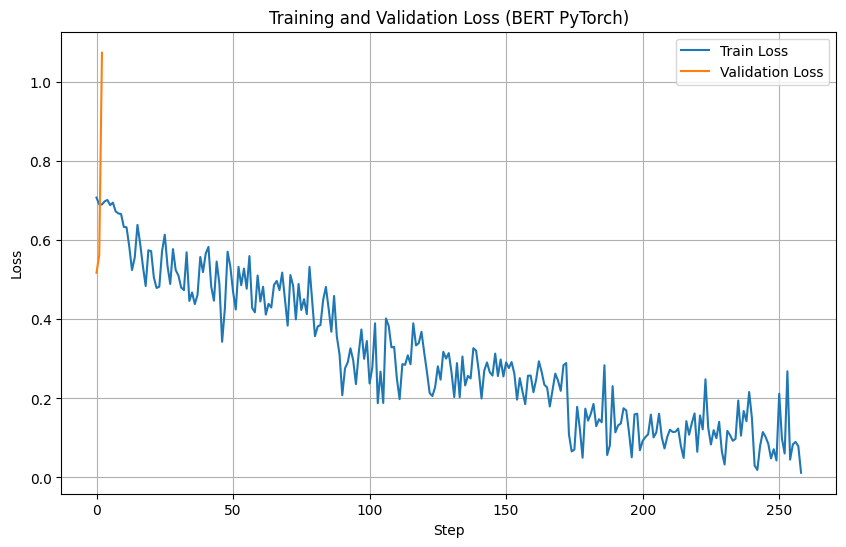

```python
import torch
from transformers import BertTokenizer, BertForSequenceClassification, Trainer, TrainingArguments
from sklearn.metrics import accuracy_score, precision_score, recall_score, f1_score, roc_auc_score
from datasets import Dataset
import matplotlib.pyplot as plt

# Load tokenizer and model (PyTorch version)
model_name = "bert-base-uncased"
tokenizer = BertTokenizer.from_pretrained(model_name)
model = BertForSequenceClassification.from_pretrained(model_name, num_labels=2)

def tokenize_function(examples):
    return tokenizer(examples["cleaned_review"], padding="max_length", truncation=True, max_length=128)

train_dataset = Dataset.from_pandas(augmented_train_df)
val_dataset = Dataset.from_pandas(val_df)

train_dataset = train_dataset.rename_column("sentiment", "labels")
val_dataset = val_dataset.rename_column("sentiment", "labels")

tokenized_train = train_dataset.map(tokenize_function, batched=True)
tokenized_val = val_dataset.map(tokenize_function, batched=True)

tokenized_train.set_format('torch', columns=['input_ids', 'attention_mask', 'labels'])
tokenized_val.set_format('torch', columns=['input_ids', 'attention_mask', 'labels'])

training_args = TrainingArguments(
    output_dir="./results",
    num_train_epochs=3,
    per_device_train_batch_size=16,
    per_device_eval_batch_size=64,
    warmup_steps=500,
    weight_decay=0.01,
    logging_dir='./logs',
    logging_steps=10,
    eval_strategy="epoch",
    save_strategy="epoch",
    load_best_model_at_end=True,
    metric_for_best_model="accuracy",
    report_to="none"
)

def compute_metrics(pred):
    logits, labels = pred
    predictions = np.argmax(logits, axis=-1)
    acc = accuracy_score(labels, predictions)
    return {"accuracy": acc}

trainer = Trainer(
    model=model,
    args=training_args,
    train_dataset=tokenized_train,
    eval_dataset=tokenized_val,
    compute_metrics=compute_metrics
)

train_result = trainer.train()
metrics = train_result.metrics
logs = trainer.state.log_history

#plot
train_losses = [log['loss'] for log in logs if 'loss' in log]
eval_losses = [log['eval_loss'] for log in logs if 'eval_loss' in log]

plt.figure(figsize=(10, 6))
plt.plot(train_losses, label='Train Loss')
plt.plot(eval_losses, label='Validation Loss')
plt.title('Training and Validation Loss (BERT PyTorch)')
plt.xlabel('Step')
plt.ylabel('Loss')
plt.legend()
plt.grid(True)
plt.show()
```

```python
test_dataset = Dataset.from_pandas(test_df)
test_dataset = test_dataset.rename_column("sentiment", "labels")
tokenized_test = test_dataset.map(tokenize_function, batched=True)
tokenized_test.set_format('torch', columns=['input_ids', 'attention_mask', 'labels'])
test_results = trainer.predict(tokenized_test)
print(test_results.metrics)

accuracy_BERT_aug = test_results.metrics['test_accuracy']
```

```
{'test_loss': 0.5116246938705444, 'test_accuracy': 0.8083470620538166, 'test_runtime': 12.5972, 'test_samples_per_second': 144.556, 'test_steps_per_second': 2.302}
```

```python
trainer.save_model("./trained_model/BERT1_AUG")
```

- Integrate a sentiment lexicon feature (e.g., VADER scores) into your models and assess whether it improves predictions.

```
217/217 ━━━━━━━━━━━━━━━━━━━━ 3s 6ms/step - accuracy: 0.5445 - loss: 0.6836 - val_accuracy: 0.7626 - val_loss: 0.5044
217/217 ━━━━━━━━━━━━━━━━━━━━ 1s 3ms/step - accuracy: 0.8129 - loss: 0.4090 - val_accuracy: 0.7511 - val_loss: 0.5867
217/217 ━━━━━━━━━━━━━━━━━━━━ 1s 3ms/step - accuracy: 0.9213 - loss: 0.1987 - val_accuracy: 0.7397 - val_loss: 0.7810
217/217 ━━━━━━━━━━━━━━━━━━━━ 1s 3ms/step - accuracy: 0.9755 - loss: 0.0756 - val_accuracy: 0.7385 - val_loss: 0.9756
217/217 ━━━━━━━━━━━━━━━━━━━━ 1s 3ms/step - accuracy: 0.9884 - loss: 0.0344 - val_accuracy: 0.7317 - val_loss: 1.1175
217/217 ━━━━━━━━━━━━━━━━━━━━ 1s 3ms/step - accuracy: 0.9918 - loss: 0.0211 - val_accuracy: 0.7213 - val_loss: 1.2254
217/217 ━━━━━━━━━━━━━━━━━━━━ 1s 3ms/step - accuracy: 0.9929 - loss: 0.0164 - val_accuracy: 0.7144 - val_loss: 1.2684
217/217 ━━━━━━━━━━━━━━━━━━━━ 1s 3ms/step - accuracy: 0.9933 - loss: 0.0139 - val_accuracy: 0.7156 - val_loss: 1.3139
217/217 ━━━━━━━━━━━━━━━━━━━━ 1s 3ms/step - accuracy: 0.9936 - loss: 0.0127 - val_accuracy: 0.7190 - val_loss: 1.3733
217/217 ━━━━━━━━━━━━━━━━━━━━ 1s 3ms/step - accuracy: 0.9937 - loss: 0.0122 - val_accuracy: 0.7190 - val_loss: 1.4309
217/217 ━━━━━━━━━━━━━━━━━━━━ 1s 3ms/step - accuracy: 0.9937 - loss: 0.0119 - val_accuracy: 0.7144 - val_loss: 1.4692
217/217 ━━━━━━━━━━━━━━━━━━━━ 1s 3ms/step - accuracy: 0.9937 - loss: 0.0117 - val_accuracy: 0.7179 - val_loss: 1.5038
217/217 ━━━━━━━━━━━━━━━━━━━━ 1s 3ms/step - accuracy: 0.9937 - loss: 0.0115 - val_accuracy: 0.7167 - val_loss: 1.5325
217/217 ━━━━━━━━━━━━━━━━━━━━ 1s 3ms/step - accuracy: 0.9938 - loss: 0.0113 - val_accuracy: 0.7167 - val_loss: 1.5596
217/217 ━━━━━━━━━━━━━━━━━━━━ 1s 3ms/step - accuracy: 0.9938 - loss: 0.0112 - val_accuracy: 0.7167 - val_loss: 1.5802
MLP with VADER - Test Accuracy: 0.7386051416397095
```

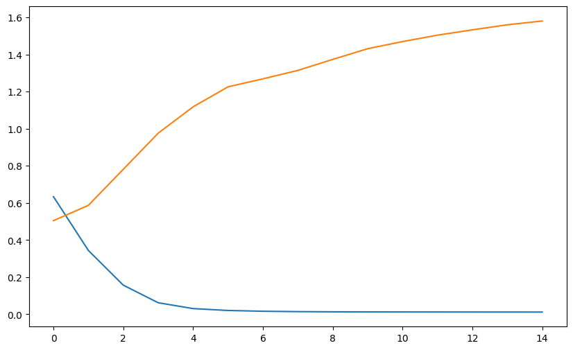

```python
import tensorflow as tf
from tensorflow.keras.models import Sequential
from tensorflow.keras.layers import Embedding, Dense, Flatten
from vaderSentiment.vaderSentiment import SentimentIntensityAnalyzer

# Initialize VADER sentiment analyzer
analyzer = SentimentIntensityAnalyzer()

def get_vader_scores(text):
  scores = analyzer.polarity_scores(text)
  return scores['compound']  # Use the compound score

# Calculate VADER scores for each review
train_df['vader_score'] = train_df['cleaned_review'].apply(get_vader_scores)
val_df['vader_score'] = val_df['cleaned_review'].apply(get_vader_scores)
test_df['vader_score'] = test_df['cleaned_review'].apply(get_vader_scores)

# Concatenate VADER scores with existing features
# Example for MLP:
X_train_vader = np.concatenate((X_train_seq, train_df['vader_score'].values.reshape(-1, 1)), axis=1)
X_val_vader = np.concatenate((X_val_seq, val_df['vader_score'].values.reshape(-1, 1)), axis=1)
X_test_vader = np.concatenate((X_test_seq, test_df['vader_score'].values.reshape(-1, 1)), axis=1)

vocab_size = len(tokenizer.word_index) + 1
embedding_dim = 100

# Modify the input shape of the MLP model
def build_mlp_model_vader(freeze_embeddings=False):
    model = Sequential()
    model.add(Embedding(vocab_size, embedding_dim, input_length=max_sequence_length))
    if freeze_embeddings:
        model.layers[0].trainable = False
    model.add(Flatten())
    model.add(Dense(128, activation='relu', input_shape=(max_sequence_length + 1,))) # +1 for vader
    model.add(Dense(1, activation='sigmoid'))
    model.compile(optimizer='adam', loss='binary_crossentropy', metrics=['accuracy'])
    return model

mlp_vader_model = build_mlp_model_vader()
mlp_vader_history = mlp_vader_model.fit(X_train_vader, train_df['sentiment'], epochs=15,
                                        validation_data=(X_val_vader, val_df['sentiment']))

mlp_vader_loss, mlp_vader_accuracy = mlp_vader_model.evaluate(X_test_vader, test_df['sentiment'], verbose=0)
print(f"MLP with VADER - Test Accuracy: {mlp_vader_accuracy}")

plt.figure(figsize=(10, 6))
plt.plot(mlp_vader_history.history['loss'], label='Train Loss')
plt.plot(mlp_vader_history.history['val_loss'], label='Val Loss')
```

- Deploy your best model as a simple REST API using Flask or FastAPI and demo it on a handful of user‐submitted reviews.

```
from flask import Flask, request, jsonify
import torch
from transformers import BertTokenizer, BertForSequenceClassification

app = Flask(__name__)

# Load the fine-tuned BERT model and tokenizer
model_name = "bert-base-uncased"
tokenizer = BertTokenizer.from_pretrained(model_name)
model = BertForSequenceClassification.from_pretrained("./trained_model/BERT1") # model's path
model.eval()

# Function to preprocess and predict
def predict_sentiment(text):
    inputs = tokenizer(text, padding=True, truncation=True, return_tensors="pt")
    with torch.no_grad():
        outputs = model(**inputs)
        logits = outputs.logits
    predicted_class = torch.argmax(logits, dim=-1).item()
    return predicted_class  # 0 for negative, 1 for positive

@app.route('/predict', methods=['POST'])
def predict():
    data = request.get_json()
    text = data['text']
    prediction = predict_sentiment(text)
    sentiment = "Positive" if prediction == 1 else "Negative"
    return jsonify({'sentiment': sentiment})

if __name__ == '__main__':
    app.run(debug=True, host='0.0.0.0', port=5000) # Run on all interfaces
```

# Reflecting

**Answer the following inference questions:**

### Part 1 – Data Ingestion & Preprocessing

1. **Data Loading**
   - How do you ensure that your dataset is properly split into training, validation, and test sets, and why is class balance important during data splitting?
   - A: To properly split the dataset into training, validation, and test sets, the best method is to used stratified sampling (`train_test_split` with `stratify=y`) to preserve the original class distribution across splits. However, in this project we did not use that explicitly since we have already have nice stratified data split from github. However, Class balance during splitting is important because models can become biased toward the majority class if the splits are imbalanced, leading to poor generalization, especially for minority classes.
2. **Text Cleaning & Tokenization**
   - What is the role of tokenization in text preprocessing, and how does it impact the model's performance?
   - A: Tokenization breaks down text into individual tokens (words, subwords, or characters), enabling the model to work with discrete numerical inputs. Proper tokenization ensures that word boundaries, punctuation, and rare words are handled consistently, which can significantly impact model performance, especially for NLP tasks.

### Part 2 – Exploratory Data Analysis (EDA)

1. **Class Distribution**
   - How does the class distribution (positive vs negative reviews) impact the model’s performance, and what strategies can be used if the dataset is imbalanced?
   - A: The dataset has a neligible imbalance between positive and negative reviews. Imbalanced datasets can cause models to favor the majority class, reducing sensitivity to the minority class. Techniques like oversampling, undersampling, or class weighting are common strategies to address this.
2. **Text Characteristics**
   - What insights can be gained from visualizing word clouds for each sentiment class, and how can it improve feature engineering?
   - A: Visualizing word clouds revealed distinctive frequent words in positive and negative reviews. From our result, we find that the most common words are common in both subsamples, such as "film" or "movie". This may mean that we could deal with those common words more carefully, for example removing them to better illustratet the difference across positive and negative word distribution.

### Part 3 – Baseline Traditional Models

1. **Logistic Regression & SVM**
   - Why do you use cross-validation when training models like logistic regression or SVM, and how does it help prevent overfitting?
   - A: Cross-validation (5-fold CV) was used to ensure the model's performance is consistent across different subsets of the data, helping detect overfitting early. Cross-validation provides a more reliable estimate of out-of-sample performance and helps in hyperparameter tuning.
2. **Random Forest & Gradient Boosting**
   - What role does feature importance play in interpreting Random Forest or XGBoost models?
   - A: Feature importance scores from Random Forest and XGBoost show which words or tokens contribute most to classification decisions. This aids interpretability and can also guide feature selection to simplify the model without major loss in performance.

### Part 4 – Neural Network Models

1. **Simple Feed-Forward**
   - Why is embedding freezing used when training neural networks on pre-trained embeddings, and how does it affect model performance?
   - A: Freezing the pre-trained embedding layer prevents updates during backpropagation, preserving valuable semantic information learned from large corpora. This leads to faster convergence and prevents overfitting, especially on small datasets.
2. **Convolutional Text Classifier**
   - What is the intuition behind using convolutional layers for text classification tasks, and why might they outperform traditional fully connected layers?
   - A: Convolutional layers, especially 1D ones, act as n-gram feature detectors, capturing local patterns like phrases or small groups of words. CNNs can outperform fully connected layers in text tasks because they better preserve spatial relationships between words.

### Part 6 – Hyperparameter Optimization

1. **Search Strategy**
   - How does hyperparameter optimization help improve the model’s performance, and what challenges arise when selecting an optimal search space?
   - A: Hyperparameter optimization (random search and Keras Tuner) systematically tests various combinations to find the best-performing model.Challenges include large search spaces, risk of overfitting to validation data, and computational costs.
2. **Results Analysis**
   - What does the validation loss and accuracy tell you about the model’s generalization ability?
   - A: Monitoring validation loss and accuracy helps assess whether the model is overfitting (validation loss increasing while training loss decreases) or underfitting (both losses high). Good generalization is indicated by similar training and validation performance.

### Part 8 – Optional Challenge Extensions

1. **Data Augmentation**
   - How does back-translation or synonym swapping as text augmentation improve model generalization?
   - A: Back-translation and synonym swapping increase dataset diversity, allowing the model to generalize better to slight variations in input phrasing. These methods help especially in low-resource settings where labeled data is limited.
2. **Sentiment Lexicon**
   - How might integrating sentiment lexicons like VADER improve the sentiment classification model, and what are the challenges of using lexicon-based approaches alongside machine learning models?
   - A: Integrating sentiment lexicons like VADER can inject domain knowledge into the model, improving performance, especially on small datasets. Challenges include rigidity (lexicons don't adapt well to context) and integration complexity with machine-learned features.